# INVENTARIOGERALCOLETOR

**Inventário padrão**

Efetue o login no sistema utilizando seu código de acesso e clicando em “**Entrar**”.

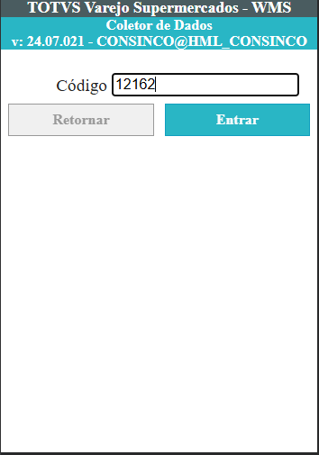

Clique na opção “**Inventário**”.

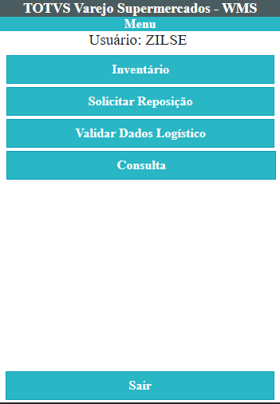

Clique na opção “**Inventário Padrão**”.

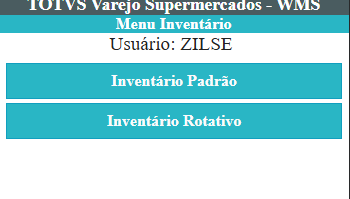

Agora você pode ver na tela o numero do lote, a quantidade de contagens a serem realizadas e a descrição do inventário. Para iniciar o inventário clique em “**Continuar**”.

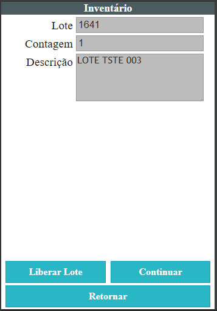

Na tela agora você verá a relação com todos os endereços a serem inventariados. Clique no endereço e bipe na etiqueta do endereço que está na longarina para iniciar o inventário.

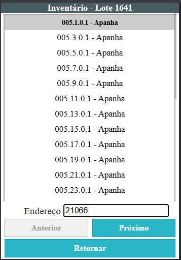

Agora na tela você já pode bipar na caixa do produto para iniciar a contagem. Digite agora a quantidade de unidades por caixa e tecle “**Enter**” no teclado

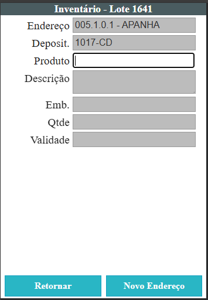

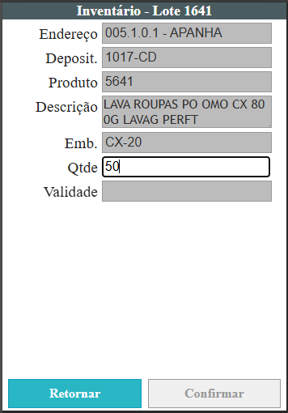

Em seguida a validade e tecle “**Enter**”.

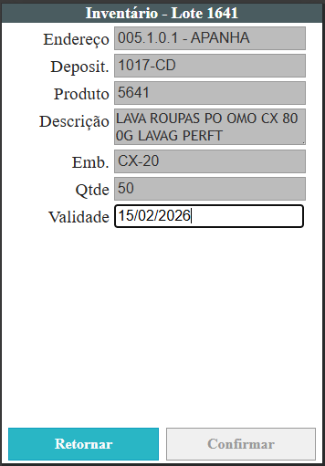

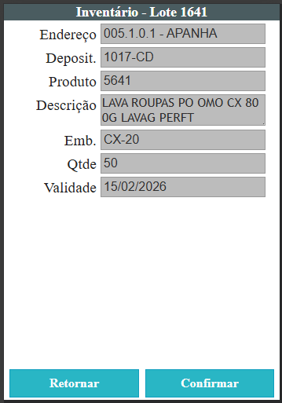

Clique em confirmar e aparecerá a tela a mensagem de confirmação “**Endereço Contado**”, clique em confirma e o sistema retornará para a tela de endereços, e o endereço que foi inventariado ficará na cor vermelha. Vá até o próximo endereço, bipe na etiqueta e siga até ter contado todos.

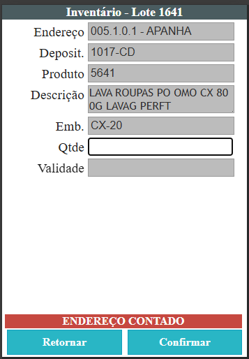

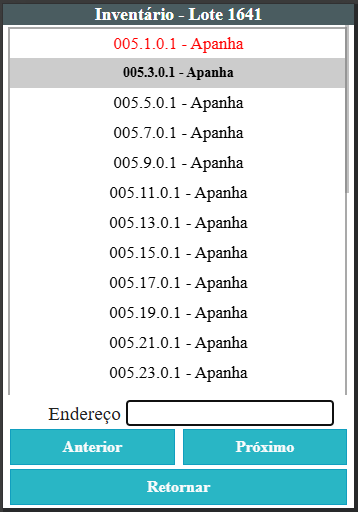

Quando finalizar todos os endereços, clique em “**Retornar**” em seguida na tecla “**Liberar Lote**” para encerrar o inventário.

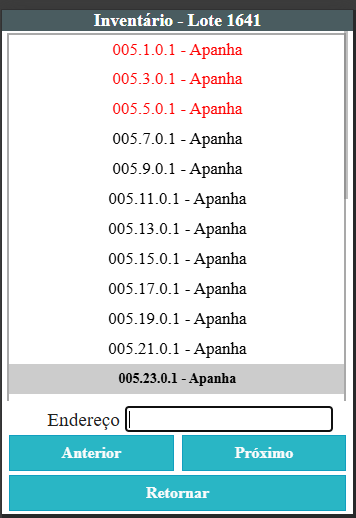

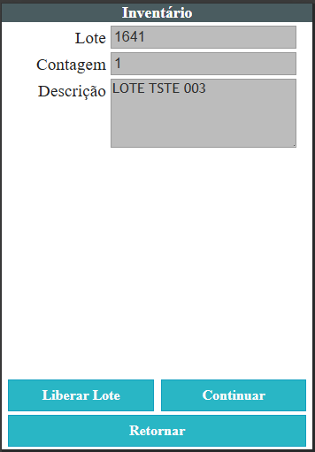

Clique em “**Confirmar**” e em seguida vai aparecer na tela a mensagem confirmando que não existe mais lotes de inventário. É só informar ao analista o fim da atividade.

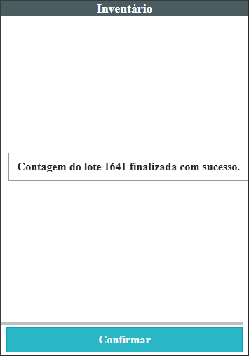

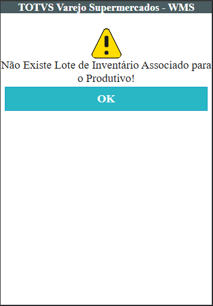

[figure not shown]

[figure not shown]

**INVENTÁRIO PADRÃO - COLETOR**